# CUNEF MUCD 2022/2023

# Machine Learning

## Analisis of Yelp Dataset

by Gozde Yazganoglu

In this notebook we will try to understand which characteristics are important for successful restaurant. We will check for open restaurants and restaurants with higher valorations. In the previous notebook we have divided the restaurants dataset into several variables. Some of them might have similar information or can be least important

### Preparations for further Analisis.

#### Importing necessary libraries.

```python
import pandas as pd
import numpy as np
import sklearn
from sklearn import metrics
import category_encoders as ce
import matplotlib.pyplot as plt
import seaborn as sns

import seaborn as sns
import matplotlib.pyplot as plt
from sklearn.preprocessing import StandardScaler
from sklearn.feature_selection import SelectFromModel
from sklearn.linear_model import LogisticRegression
from sklearn.ensemble import GradientBoostingClassifier
from sklearn import metrics
from sklearn.discriminant_analysis import LinearDiscriminantAnalysis as LDA
from sklearn.model_selection import train_test_split
from sklearn.ensemble import RandomForestClassifier
from sklearn.decomposition import PCA
from aux_func import preview_data, check_missing_feautre, evaluate_model

import pickle
```

#### Importing data and setting random seed.

```python
# Path we have saved previous processed pickle formated data.
from pathlib import Path

path_processed = '../data/processed/'
r = 42
```

```python
with open(Path(path_processed, 'restaurants.pkl'), 'rb') as f:
    # Load the data from the file
    restaurants = pickle.load(f)
```

```python
preview_data(restaurants)
```

```
Dataset has  5854 rows and  96 columns
```

|  | business_id | name | address | city | state | postal_code | latitude | longitude | stars | review_count | ... | Monday | Tuesday | Wednesday | Thursday | Friday | Saturday | Sunday | compliment_count | elite | friend_count |
| --- | --- | --- | --- | --- | --- | --- | --- | --- | --- | --- | --- | --- | --- | --- | --- | --- | --- | --- | --- | --- | --- |
| 0 | MTSW4McQd7CbVtyjqoe9mw | St Honore Pastries | 935 Race St | Philadelphia | PA | 19107 | 39.955505 | -75.155564 | 4.0 | 80 | ... | True | True | True | True | True | True | True | 0.0 | 0.0 | 0.0 |
| 1 | MUTTqe8uqyMdBl186RmNeA | Tuna Bar | 205 Race St | Philadelphia | PA | 19106 | 39.953949 | -75.143226 | 4.0 | 245 | ... | False | True | True | True | True | True | True | 0.0 | 0.0 | 0.0 |
| 2 | ROeacJQwBeh05Rqg7F6TCg | BAP | 1224 South St | Philadelphia | PA | 19147 | 39.943223 | -75.162568 | 4.5 | 205 | ... | True | True | True | True | True | True | False | 0.0 | 0.0 | 1.0 |
| 3 | QdN72BWoyFypdGJhhI5r7g | Bar One | 767 S 9th St | Philadelphia | PA | 19147 | 39.939825 | -75.157447 | 4.0 | 65 | ... | True | True | True | True | True | True | True | 0.0 | 0.0 | 0.0 |
| 4 | Mjboz24M9NlBeiOJKLEd_Q | DeSandro on Main | 4105 Main St | Philadelphia | PA | 19127 | 40.022466 | -75.218314 | 3.0 | 41 | ... | False | True | True | True | True | True | True | 0.0 | 0.0 | 0.0 |

5 rows × 96 columns

Below variables are not necessary, all city and state variables are now similar, adresss information can be found in lattitude, longitude. name and business_id are similarly distinct for every single variable.

```python
restaurants = restaurants.drop(columns=['business_id','name','address', 'city', 'state', 'is_rest',
                                        'postal_code','categories'])
```

#### Codification of objective variable.

We are going to understand, what is necessary to see receive a rating more or equal to 4. We choose stars as target variable. As we have checked before some of the closed restaurants also has this rating as well.

In order to use in classification model, we change this state to 1 or zeros.

```python
restaurants['stars4'] = restaurants['stars'].apply(lambda x: 1 if x >= 4 else 0)

weekdays=['Monday', 'Tuesday', 'Wednesday', 'Thursday', 'Friday', 'Saturday', 'Sunday']
```

```python
xtrain_4, xtest_4, ytrain_4, ytest_4 = train_test_split(restaurants.drop(columns=['stars4','stars']),
                                                restaurants['stars4'],
                                                test_size=0.20,
                                                random_state=r,
                                                stratify= restaurants['stars4'])
```

Since we had to manipulate variables more in details, we have processed already categorical variables. We do not need to encode again. We have now only numeric and boolean data. Booleans can be used in some of the machine learning algorithms. We will try in this way.

#### Scaling of Varibles

We have created a lot of variables. Probably some of them are quite corralated to each other or doesn't have a lot of importance. We cannot know without selection of the variables. I will here check first ridge and Lasso regression and later we will follow with PCA and LDA in order to stay with most used components.

We for sure require sccaling in order to process standardization for Ridge regression because the regularized variables require it.

```python
scaler = StandardScaler()
model_scaled = scaler.fit(xtrain_4)
x4_train = pd.DataFrame(scaler.transform(xtrain_4), columns = xtrain_4.columns, index = xtrain_4.index)
x4_test = pd.DataFrame(scaler.transform(xtest_4), columns  = xtrain_4.columns, index = xtest_4.index)
```

## 2. Variable Selection

### 2.1.Ridge Regression

Ridge regression is linearilized version of regularization term l2. This forces learning algorithm to not only to fit the data but also keep the model weights as small as possible.

We will use SelectFromModel module of sklearn

```python
sel_ridge = SelectFromModel(LogisticRegression(C=1, penalty='l2'), threshold = 0.009)
sel_ridge.fit(x4_train, ytrain_4)
```

```
SelectFromModel(estimator=LogisticRegression(C=1), threshold=0.009)
```

[figure not shown]

```python
# Ridge Coefficients
# ==============================================================================
ridge_coef = pd.DataFrame(
                        {'predictor': x4_train.columns,
                         'coef': sel_ridge.estimator_.coef_.flatten()}
                  )


# Sort the DataFrame by the coef column in ascending order
ridge_coef = ridge_coef.sort_values(by='coef', ascending=True)

# Plot the stem plot
fig, ax = plt.subplots(figsize=(15, 5))
ax.stem(ridge_coef.predictor, ridge_coef.coef, markerfmt=' ')
plt.xticks(rotation=90, ha='right', size=10)
ax.set_xlabel('variables')
ax.set_ylabel('coeficients')
ax.set_title('Coefficients of Lasso Regularization')
```

```python
sel_ridge.get_support()
selected_ridge = x4_train.columns[sel_ridge.get_support()]
selected_ridge
```

```
Index(['latitude', 'longitude', 'review_count', 'is_open',
       'RestaurantsDelivery', 'OutdoorSeating', 'BusinessAcceptsCreditCards',
       'BusinessParking', 'BikeParking', 'RestaurantsPriceRange2',
       'RestaurantsTakeOut', 'ByAppointmentOnly', 'WiFi', 'Alcohol',
       'RestaurantsReservations', 'RestaurantsGoodForGroups',
       'RestaurantsAttire', 'HasTV', 'Ambience', 'GoodForKids', 'GoodForMeal',
       'NoiseLevel', 'DogsAllowed', 'HappyHour', 'RestaurantsTableService',
       'Smoking', 'Music', 'BusinessAcceptsBitcoin', 'BestNights', 'Corkage',
       'BYOBCorkage', 'BYOB', 'DriveThru', 'AgesAllowed',
       'RestaurantsCounterService', 'Turkish', 'Italian', 'Seafood', 'Asian',
       'Chinese', 'Indian', 'American', 'Fast Food', 'Spanish', 'Sushi',
       'Pizza', 'Tapas', 'Steakhouse', 'Kosher', 'Halal', 'Tex-Mex', 'Cafe',
       'Bar', 'Pub', 'Bistro', 'Latin', 'Korean', 'Nightlife', 'Soup',
       'Cocktail', 'Tea', 'Bakeries', 'Monday', 'Tuesday', 'Wednesday',
       'Thursday', 'Friday', 'Saturday', 'Sunday', 'compliment_count', 'elite',
       'friend_count'],
      dtype='object')
```

```python
print('total features: {}'.format((x4_train.shape[1])))
print('selected features: {}'.format(len(selected_ridge)))
```

```
total features: 87
selected features: 72
```

Ridge regression has selected 72 variables among 87. The most important variables are friday and review count.

```python
x4_train[selected_ridge].shape
```

```
(4683, 72)
```

### Lasso regression

Least Absolute Shrinkage and Selection Operator (Lasso) uses l1 normalization.

```python
sel_lasso = SelectFromModel(LogisticRegression(C=1, penalty='l1',
                                          solver='liblinear'), threshold = 0.009)
sel_lasso.fit(x4_train, ytrain_4)
```

```
SelectFromModel(estimator=LogisticRegression(C=1, penalty='l1',
                                             solver='liblinear'),
                threshold=0.009)
```

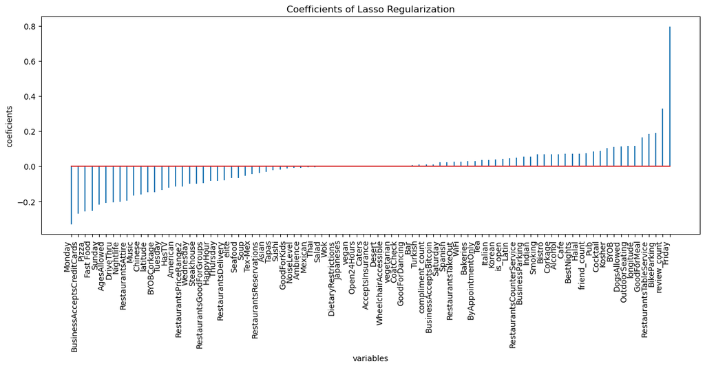

```python
# Lasso Coefficients
# ==============================================================================
lasso_coef = pd.DataFrame(
                        {'predictor': x4_train.columns,
                         'coef': sel_lasso.estimator_.coef_.flatten()}
                  )


# Sort the DataFrame by the coef column in ascending order
lasso_coef = lasso_coef.sort_values(by='coef', ascending=True)

# Plot the stem plot
fig, ax = plt.subplots(figsize=(15, 5))
ax.stem(lasso_coef.predictor, lasso_coef.coef, markerfmt=' ')
plt.xticks(rotation=90, ha='right', size=10)
ax.set_xlabel('variables')
ax.set_ylabel('coeficients')
ax.set_title('Coefficients of Lasso Regularization')
```

```python
lasso_coef
```

|  | predictor | coef |
| --- | --- | --- |
| 77 | Monday | -0.331591 |
| 6 | BusinessAcceptsCreditCards | -0.270149 |
| 55 | Pizza | -0.257538 |
| 51 | Fast Food | -0.253745 |
| 83 | Sunday | -0.218933 |
| ... | ... | ... |
| 21 | GoodForMeal | 0.163266 |
| 26 | RestaurantsTableService | 0.184977 |
| 8 | BikeParking | 0.189031 |
| 2 | review_count | 0.330306 |
| 81 | Friday | 0.796608 |

87 rows × 2 columns

```python
sel_lasso.get_support()
selected_lasso = x4_train.columns[sel_lasso.get_support()]
selected_lasso
```

```
Index(['latitude', 'longitude', 'review_count', 'is_open',
       'RestaurantsDelivery', 'OutdoorSeating', 'BusinessAcceptsCreditCards',
       'BusinessParking', 'BikeParking', 'RestaurantsPriceRange2',
       'RestaurantsTakeOut', 'ByAppointmentOnly', 'WiFi', 'Alcohol',
       'RestaurantsReservations', 'RestaurantsGoodForGroups',
       'RestaurantsAttire', 'HasTV', 'Ambience', 'GoodForKids', 'GoodForMeal',
       'NoiseLevel', 'DogsAllowed', 'HappyHour', 'RestaurantsTableService',
       'Smoking', 'Music', 'BusinessAcceptsBitcoin', 'BestNights', 'Corkage',
       'BYOBCorkage', 'BYOB', 'DriveThru', 'AgesAllowed',
       'RestaurantsCounterService', 'Italian', 'Seafood', 'Asian', 'Chinese',
       'Indian', 'American', 'Fast Food', 'Spanish', 'Sushi', 'Pizza', 'Tapas',
       'Steakhouse', 'Kosher', 'Halal', 'Tex-Mex', 'Cafe', 'Pub', 'Bistro',
       'Latin', 'Korean', 'Nightlife', 'Soup', 'Cocktail', 'Tea', 'Bakeries',
       'Monday', 'Tuesday', 'Wednesday', 'Thursday', 'Friday', 'Saturday',
       'Sunday', 'compliment_count', 'elite', 'friend_count'],
      dtype='object')
```

```python
print('total features: {}'.format((x4_train.shape[1])))
print('selected features: {}'.format(len(selected_lasso)))
```

```
total features: 87
selected features: 70
```

Lasso regularization has reduced to 70 variables Turkish and Bar variables were additionally removed in this model. We can go on with Lasso model as we would like to diferenciate more. Most important variables are review count and Friday availablity.

Unlike my primary assumptions, 'vegan' or 'vegetarian' choices are penalized while Kosher and Halal options remained important in both selections. Most important attributes are bike parking, table service and outdoor seats.

```python
x4_train[selected_lasso].shape
```

```
(4683, 70)
```

### Principal Component Analisis

We will apply PCA to reduced variables by following below steps. Since we have a lot of variables we would like to reduce dimension in this analisis.

```
1. Standardize the data:
2. Compute the covariance matrix:
3. Compute the eigenvalues and eigenvectors:
4. Sort the eigenvalues and eigenvectors:
5. Project the data onto the lower-dimensional space:
```

```python
pca = PCA(n_components=36)
#after trying without componenet 36 components fall under threshold

pca.fit(x4_train[selected_lasso])#according to Lasso selection
X_train_pca = pca.transform(x4_train[selected_lasso])
X_test_pca = pca.transform(x4_test[selected_lasso])
```

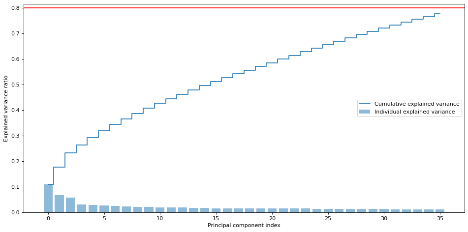

```python
exp_var_pca = pca.explained_variance_ratio_# finding set of explained variances of the PCA components


cum_sum_eigenvalues = np.cumsum(exp_var_pca)# cumulative sum of explained variances

#graphing individual variances and cumulative variances.

threshold = 0.80
plt.figure(figsize=(12, 6), dpi=80)
plt.bar(range(0,len(exp_var_pca)), exp_var_pca, alpha=0.5, align='center', label='Individual explained variance')
plt.step(range(0,len(cum_sum_eigenvalues)), cum_sum_eigenvalues, where='mid',label='Cumulative explained variance')
plt.axhline(y=threshold, color='r', linestyle='-')

plt.ylabel('Explained variance ratio')
plt.xlabel('Principal component index')
plt.legend(loc='best')
plt.tight_layout()
plt.show()
```

```python
exp_var_pca
```

```
array([0.10988846, 0.0663162 , 0.05718673, 0.03035866, 0.0285259 ,
       0.02648679, 0.02500393, 0.0220525 , 0.02102474, 0.0200033 ,
       0.01934998, 0.01829639, 0.0179453 , 0.01710715, 0.01621234,
       0.01545143, 0.01524113, 0.01518428, 0.01484267, 0.01464192,
       0.01451923, 0.01427614, 0.01424643, 0.01404938, 0.01396587,
       0.01367343, 0.01346534, 0.0132569 , 0.01296377, 0.01265215,
       0.01231653, 0.01192959, 0.01169326, 0.01120083, 0.01092865,
       0.01056168])
```

### LDA

LDA selection is similar to PCA but we use variance matrix instead of covariance matrix.

```python
lda = LDA()# we are not fixing any number of the components.

lda.fit(x4_train, ytrain_4)
X_train_lda = lda.transform(x4_train)
X_test_lda = lda.transform(x4_test)
```

```python
exp_var_lda = lda.explained_variance_ratio_
exp_var_lda

cum_sum_eigenvalues_lda = np.cumsum(exp_var_lda)# cumulative sum of explained variances
```

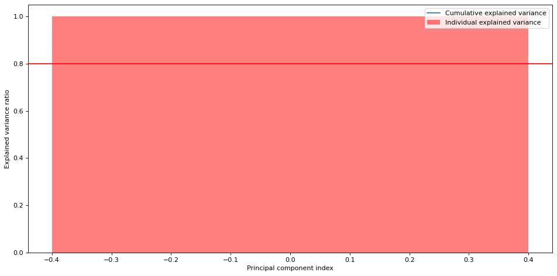

```python
threshold = 0.80
plt.figure(figsize=(12, 6), dpi=80)
plt.bar(range(0,len(exp_var_lda)), exp_var_lda, alpha=0.5, align='center', label='Individual explained variance', color='red')
plt.step(range(0,len(cum_sum_eigenvalues_lda)), cum_sum_eigenvalues_lda, where='mid',label='Cumulative explained variance')
plt.axhline(y=threshold, color='r', linestyle='-')

plt.ylabel('Explained variance ratio')
plt.xlabel('Principal component index')
plt.legend(loc='best')
plt.tight_layout()
plt.show()
```

```python
df_comp_pca = pd.DataFrame(pca.components_, columns = restaurants[selected_lasso].columns)
```

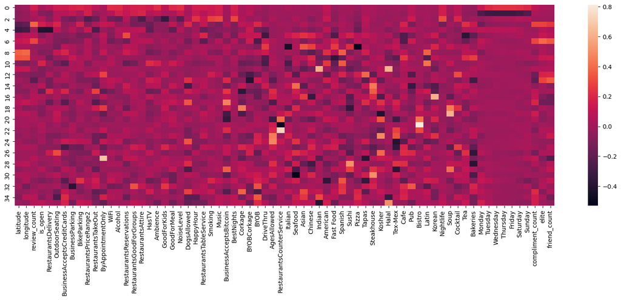

```python
plt.figure(figsize =(20, 6))
#plotting heatmap
sns.heatmap(df_comp_pca)
```

In above graph we see how much each lasso variables are important in every component we found with PCA. Some of the components have more strong with some of the variables but cosidering the percentage each of them explains, we can not infere any variable as dominating in importance. This could be also because a good number of our variables are booleans.

In conclusion, we choose reducing number of variables with Lasso regression and reducing dimension by PCA, we will deploy the models with components we are left with.

### Model Deployment

#### Gradient Boosting Model

```python
clf_xgbt = GradientBoostingClassifier(
              learning_rate=0.1,  max_depth=12,
              min_weight_fraction_leaf=0.02, n_estimators=130,
              random_state=2408,
              verbose=1)
clf_xgbt.fit(X_train_pca,ytrain_4)
```

```
      Iter       Train Loss   Remaining Time
         1           1.3423           56.18s
         2           1.3081           46.75s
         3           1.2765           43.85s
         4           1.2494           42.80s
         5           1.2258           41.91s
         6           1.2033           41.23s
         7           1.1833           40.65s
         8           1.1636           40.69s
         9           1.1462           40.29s
        10           1.1303           39.58s
        20           1.0031           35.45s
        30           0.9207           33.54s
        40           0.8576           31.83s
        50           0.8055           28.01s
        60           0.7540           24.56s
        70           0.7115           21.34s
        80           0.6839           18.28s
        90           0.6479           14.67s
       100           0.6163           10.86s
```

```
GradientBoostingClassifier(max_depth=12, min_weight_fraction_leaf=0.02,
                           n_estimators=130, random_state=2408, verbose=1)
```

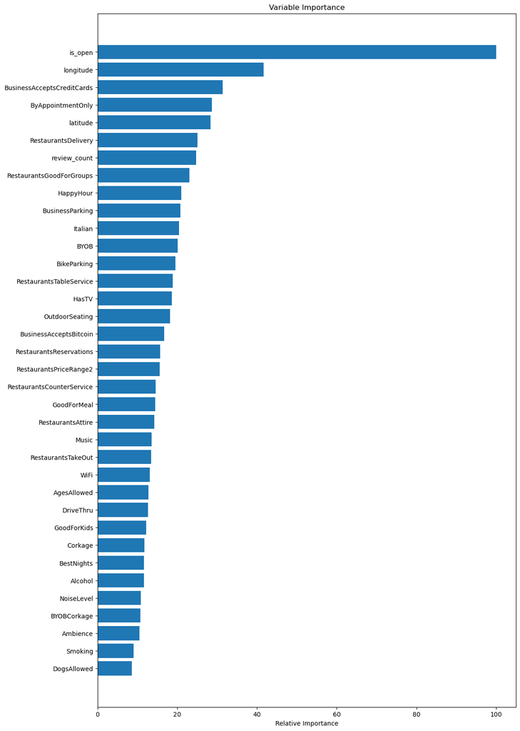

```python
feature_importance = clf_xgbt.feature_importances_
# make importances relative to max importance
feature_importance = 100.0 * (feature_importance / feature_importance.max())
sorted_idx = np.argsort(feature_importance)
pos = np.arange(sorted_idx.shape[0]) + .5
# plt.subplot(1, 2, 2)
plt.figure(figsize=(12, 20))
plt.barh(pos, feature_importance[sorted_idx], align='center')
plt.yticks(pos,df_comp_pca.keys()[sorted_idx])
plt.xlabel('Relative Importance')
plt.title('Variable Importance')
plt.show()
```

```python
pred_test = clf_xgbt.predict_proba(X_test_pca)
pred_train = clf_xgbt.predict_proba(X_train_pca)
pred_train
```

```
array([[0.13161972, 0.86838028],
       [0.84134309, 0.15865691],
       [0.2474439 , 0.7525561 ],
       ...,
       [0.78541827, 0.21458173],
       [0.90216929, 0.09783071],
       [0.91088004, 0.08911996]])
```

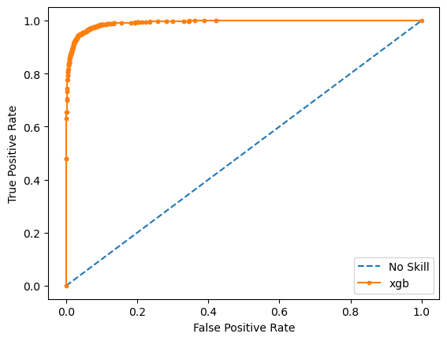

```python
# keep probabilities for the positive outcome only
yhat_train_g = pred_train[:, 1]
# calculate roc curves
fpr, tpr, thresholds = metrics.roc_curve(ytrain_4, yhat_train)
# plot the roc curve for the model
plt.plot([0,1], [0,1], linestyle='--', label='No Skill')
plt.plot(fpr, tpr, marker='.', label='xgb')
# axis labels
plt.xlabel('False Positive Rate')
plt.ylabel('True Positive Rate')
plt.legend()
# show the plot
plt.show()
```

```python
# calculate AUC
auc = metrics.roc_auc_score(ytrain_4, yhat_train_g)
print('AUC: %.3f' % auc)
```

```
AUC: 0.992
```

```python
clf_rf = RandomForestClassifier(
              max_depth=12,
              min_weight_fraction_leaf=0.02, n_estimators=130,
              random_state=r,
              verbose=1)
clf_rf.fit(X_train_pca,ytrain_4)
```

```
[Parallel(n_jobs=1)]: Using backend SequentialBackend with 1 concurrent workers.
[Parallel(n_jobs=1)]: Done 130 out of 130 | elapsed:    4.6s finished
```

```
RandomForestClassifier(max_depth=12, min_weight_fraction_leaf=0.02,
                       n_estimators=130, random_state=42, verbose=1)
```

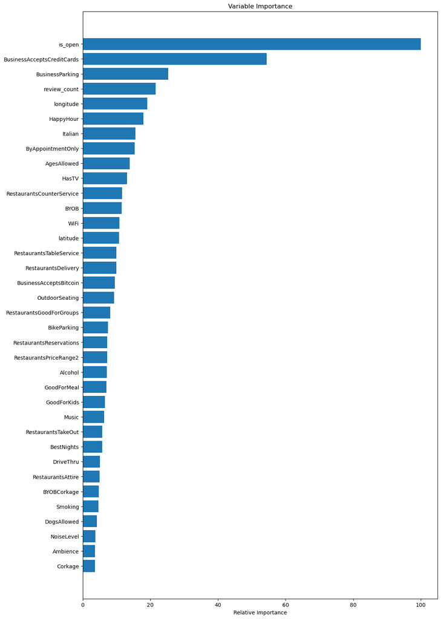

```python
feature_importance_rf = clf_rf.feature_importances_
# make importances relative to max importance
feature_importance_rf = 100.0 * (feature_importance_rf / feature_importance_rf.max())
sorted_idx = np.argsort(feature_importance_rf)
pos = np.arange(sorted_idx.shape[0]) + .5
# plt.subplot(1, 2, 2)
plt.figure(figsize=(12, 20))
plt.barh(pos, feature_importance_rf[sorted_idx], align='center')
plt.yticks(pos,df_comp_pca.keys()[sorted_idx])
plt.xlabel('Relative Importance')
plt.title('Variable Importance')
plt.show()
```

```python
pred_test_rf = clf_xgbt.predict_proba(X_test_pca)
pred_train_rf = clf_xgbt.predict_proba(X_train_pca)
```

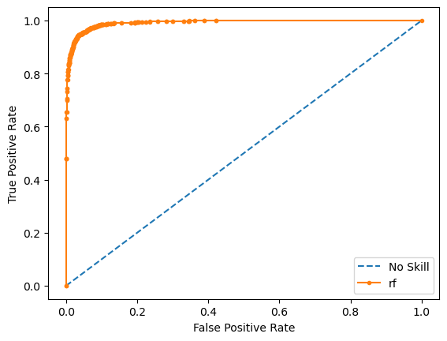

```python
# keep probabilities for the positive outcome only
yhat_train_rf = pred_train_rf[:, 1]
# calculate roc curves
fpr, tpr, thresholds = metrics.roc_curve(ytrain_4, yhat_train_rf)
# plot the roc curve for the model
plt.plot([0,1], [0,1], linestyle='--', label='No Skill')
plt.plot(fpr, tpr, marker='.', label='rf')
# axis labels
plt.xlabel('False Positive Rate')
plt.ylabel('True Positive Rate')
plt.legend()
# show the plot
plt.show()
```

```python
# calculate AUC
auc = metrics.roc_auc_score(ytrain_4, yhat_train_rf)
print('AUC: %.3f' % auc)
```

```
AUC: 0.992
```

### Interpretability

We have some idea how is should be important some variables, here with help of library shap we will check importance of the variables also according to their values. Here we will analyze Ramdom Forest model.

```python
import shap
# Need to load JS vis in the notebook
shap.initjs()
```

[output not shown]

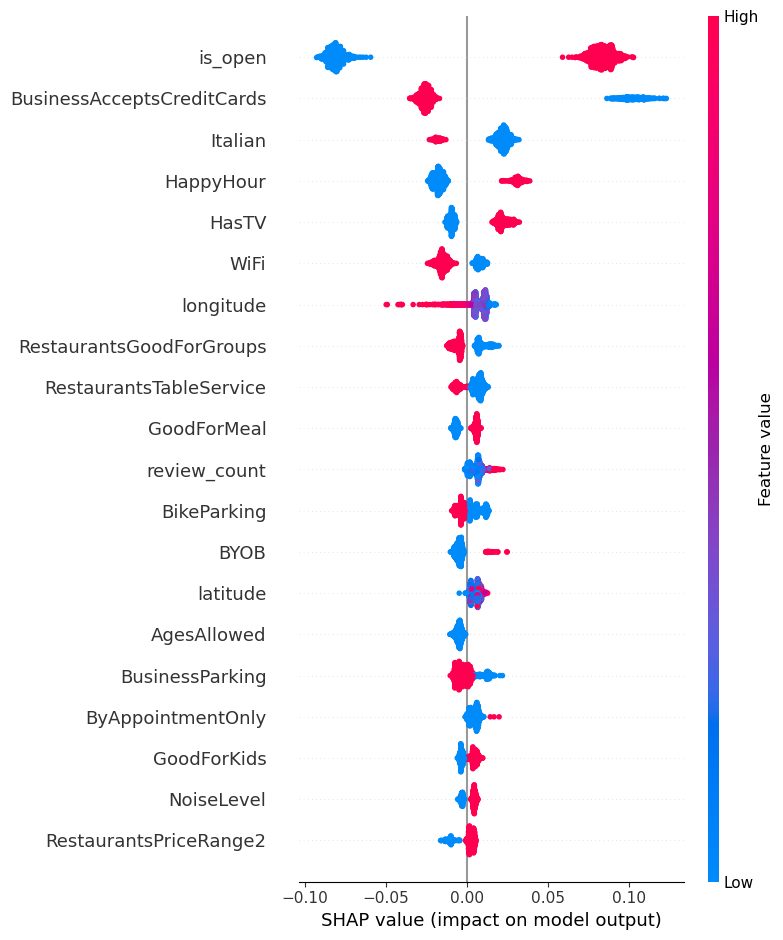

```
CPU times: user 6.97 s, sys: 1.41 s, total: 8.39 s
Wall time: 6.58 s
```

```python
%%time
explainer = shap.TreeExplainer(clf_rf)
shap_values = explainer.shap_values(x4_test[selected_lasso])
shap.summary_plot(shap_values[1],x4_test[selected_lasso])
```